# hausuebung_3

# Hausübung 3

## 📅 Formalitäten und Abgabe

- **Abgabe bis:** Freitag 12.12, 23:55 via ILIAS
- **Zip-Datei benennen:** `vorname_nachname.zip`
  - **Gerendertes Skript:** `vorname_nachname_hausuebung_3.html`
  - **Ungerendertes Quarto-Skript:** `vorname_nachname_hausuebung_3.qmd`
- **Peer Feedback:** Bis 17.12 direkt an die Person und im Forum als Zusammenfassung. Im Forum bitte auch Namen der Person, für die das Feedback bestimmt ist, nennen.

**Note**

Stelle deinen YAML-Header so ein, dass ein *table of contents* erstellt wird, `embed-resources: true` aktiviert ist und das Ausgabeformat auf `html` gesetzt wird. Dies verbessert die Leserlichkeit des Dokuments.

📥 Download therapie_bedingung.csv

📥 Download therapie_results.csv

## 📖 Datensätze “Therapie” einlesen und bereinigen

In den folgenden Daten versuchst du herauszufinden, ob sich eine neuartige Therapie von der Kontrollgruppe (Warteliste) unterscheidet. Dafür wurde das Wohlbefinden der Personen über drei Zeitpunkte hinweg gemessen (*therapie_results*). Zuerst musst du die Daten bereinigen, mergen und visualisieren und zum Schluss mit einem Hypothesentest entscheiden, ob die neue Therapieform besser abschneidet als die Kontrollgruppe.

- Lies die beiden Datensätze `therapie_Bedingung` und `therapie_results` ein.

**Lösungen**

```r
therapie_results <- read_delim("raw/therapie_results.csv",  delim = ";", escape_double = FALSE, trim_ws = TRUE)

therapie_bedingung <- read_delim("raw/therapie_bedingung.csv",  delim = ";", escape_double = FALSE, trim_ws = TRUE)
```

- Bereinge die Datensätze! Gibt es duplizierte Werte? Gibt es Missings? Gibt es unmögliche Werte?

**Lösungen**

```r
skimr::skim(therapie_bedingung)
```

Data summary

| Name | therapie_bedingung |
| --- | --- |
| Number of rows | 54 |
| Number of columns | 2 |
| _______________________ |  |
| Column type frequency: |  |
| character | 1 |
| numeric | 1 |
| ________________________ |  |
| Group variables | None |

**Variable type: character**

| skim_variable | n_missing | complete_rate | min | max | empty | n_unique | whitespace |
| --- | --- | --- | --- | --- | --- | --- | --- |
| bedingung | 0 | 1 | 14 | 14 | 0 | 2 | 0 |

**Variable type: numeric**

| skim_variable | n_missing | complete_rate | mean | sd | p0 | p25 | p50 | p75 | p100 | hist |
| --- | --- | --- | --- | --- | --- | --- | --- | --- | --- | --- |
| id | 0 | 1 | 25.28 | 14.5 | 1 | 13.25 | 24.5 | 37.75 | 50 | ▇▇▇▇▇ |

```r
skim(therapie_results)
```

Data summary

| Name | therapie_results |
| --- | --- |
| Number of rows | 50 |
| Number of columns | 4 |
| _______________________ |  |
| Column type frequency: |  |
| numeric | 4 |
| ________________________ |  |
| Group variables | None |

**Variable type: numeric**

| skim_variable | n_missing | complete_rate | mean | sd | p0 | p25 | p50 | p75 | p100 | hist |
| --- | --- | --- | --- | --- | --- | --- | --- | --- | --- | --- |
| id | 0 | 1 | 25.50 | 14.58 | 1 | 13.25 | 25.5 | 37.75 | 50 | ▇▇▇▇▇ |
| beginn | 0 | 1 | 3.62 | 1.34 | 1 | 2.80 | 3.6 | 4.60 | 6 | ▃▇▇▃▆ |
| mitte | 0 | 1 | 3.86 | 1.36 | 1 | 3.00 | 3.8 | 4.95 | 6 | ▅▃▇▅▆ |
| ende | 0 | 1 | 3.76 | 1.39 | 1 | 3.00 | 3.7 | 5.00 | 6 | ▃▅▇▇▅ |

```r
therapie_bedingung_clean <- unique(therapie_bedingung)
```

Im Datensatz `therapie_bedingung` gab es duplizierte Werte, die mit der Funktion `unique()` entfernt wurden. In beiden Datensätzen gab es keine Missings oder unmöglichen Werte.

- Merge die bereinigten Datensätze!

**Lösungen**

```r
therapie <- full_join(therapie_bedingung_clean, therapie_results, by = "id")
```

- Wandle die Variablen `id` und `bedingung` in Faktoren um.

**Lösungen**

```r
# Variablen zu Faktoren umwandeln
therapie$id <- as.factor(therapie$id)
therapie$bedingung <- as.factor(therapie$bedingung)
```

- Führe eine Wide-to-Long-Transformation durch und erstelle damit einen Dataframe `therapie_long` mit einem messwiederholten Faktor `messzeitpunkt` und der (Outcome-)Variable `wohlbefinden`. Diese setzt sich aus den Werten in `beginn`, `mitte` und `ende` zusammen.

**Lösungen**

```r
therapie_long <- therapie  |>
  pivot_longer(
    cols = c("beginn", "mitte", "ende"),
    names_to = "messzeitpunkt",
    values_to = "wohlbefinden"
    )
```

- Definiere die Variable `messzeitpunkt` als Faktor mit den Faktorstufen `beginn`, `mitte` und `ende` (in genau dieser Reihenfolge).

**Lösungen**

```r
therapie_long <-  therapie_long |>
    mutate(messzeitpunkt = factor(messzeitpunkt,
                                  levels = c("beginn", "mitte", "ende")))
levels(therapie_long$messzeitpunkt)
```

```
[1] "beginn" "mitte"  "ende"
```

## 🖌️Daten visualisieren

- Bevor wir die Daten mit Hypothesentests analysieren, wollen wir ein Gefühl für die Daten erhalten. Plotte dafür den Mittelwertsverlauf mit Fehlerbalken über die drei Zeitpunkte hinweg. Nutze den zur Verfügung gestellten Code, um ein Summary zu erstellen.

```r
summary_data <- therapie_long |>
  group_by(bedingung, messzeitpunkt) |>
  summarise(
    mean_wb = mean(wohlbefinden),
    se_wb   = sd(wohlbefinden) / sqrt(n())
  )
```

- Plotte nun die Daten. Färbe die Verlaufslinien nach Versuchsbedingung ein und gruppiere die Daten mit `color = bedingung` und `group = bedingung`. Verwende drei Geoms:
  - `geom_line()` für die Verlaufslinien
  - `geom_point()` für die einzelnen Datenpunkten
  - `geom_errorbar()` für die Fehlerbalken.
- Füge ausserdem angemessene Formatierungen hinzu (Titel, Achsenbeschriftungen, Theme).

**Lösungen**

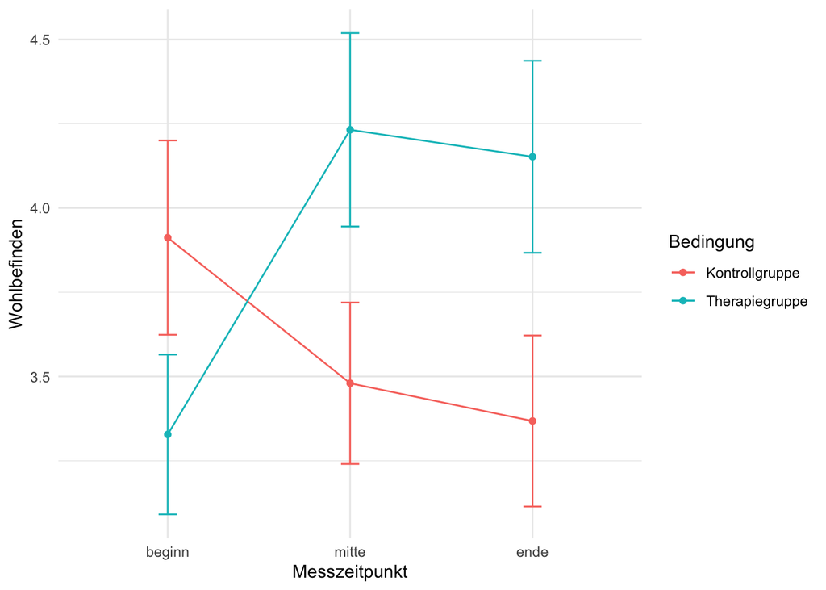

```r
ggplot(summary_data, aes(x = messzeitpunkt, y = mean_wb,
                         color = bedingung, group = bedingung)) +
  geom_line() +
  geom_point() +
  geom_errorbar(aes(ymin = mean_wb - se_wb, ymax = mean_wb + se_wb),
                width = 0.1) +
  labs(
    x = "Messzeitpunkt",
    y = "Wohlbefinden",
    color = "Bedingung"
  ) +
  theme_minimal()
```

## 📊 ANOVAs und Post-hoc t-Tests

- Ergänze dafür den Code um die nötigen Variablen. Der Test prüft gegen Varianzhomogenität; daher bedeutet ein nicht signifikantes Ergebnis, dass die Voraussetzung für die ANOVA nicht verletzt ist.

```r
leveneTest(AV ~ Gruppen, data = )
```

**Lösungen**

```r
leveneTest(wohlbefinden ~ bedingung, data = therapie_long)
```

```
Levene's Test for Homogeneity of Variance (center = median)
       Df F value Pr(>F)
group   1   0.485 0.4873
      148
```

Der Levene-Test ist nicht signifikant (p > .05), somit ist die Voraussetzung der Varianzhomogenität über die verschiedenen Gruppen hinweg erfüllt.

- Führe eine Mixed-Design-ANOVA mit `aov_4()` (aus dem Paket “afex”) durch. Die abhängige Variable ist *`wohlbefinden`*, der unabhängige Between-Faktor ist *`bedingung`* und der unabhängige Within-Faktor ist *`messzeitpunkt`*. Die Formel für die ANOVA lautet: AV ~ Between-Faktor + (Within-Faktor). Für den Within-Faktor verwenden wir die folgende Schreibweise: *`(messzeitpunkt | id)`*, da die Messwiederholungen innerhalb jeder Person verschachtelt sind.

**Passe den Code an:**

```r
anova_1 <- aov_4(AV ~ between_subjects_faktor + (messzeitpunkt | id) data = ))

summary(anova_1)
```

**Note**

Schaue dir die Ergebnisse einschliesslich des Mauchly-Tests auf Sphärizität an – dieser ist relevant bei mindestens drei Within-Faktoren. Der Mauchly-Test sollte nicht signifikant sein, sodass wir Sphärizität annehmen können (ähnlich zum Levene Test). Falls doch: Werte nach Greenhouse-Geisser-Korrektur interpretieren.

**Lösungen**

```r
anova_1 <- aov_4(wohlbefinden ~ bedingung + (messzeitpunkt | id),
                      data = therapie_long)

summary(anova_1)
```

```
Univariate Type III Repeated-Measures ANOVA Assuming Sphericity

                         Sum Sq num Df Error SS den Df  F value    Pr(>F)
(Intercept)             2104.13      1  196.775     48 513.2660 < 2.2e-16 ***
bedingung                  3.78      1  196.775     48   0.9212     0.342
messzeitpunkt              1.41      2   57.833     96   1.1691     0.315
bedingung:messzeitpunkt   15.24      2   57.833     96  12.6481 1.332e-05 ***
---
Signif. codes:  0 '***' 0.001 '**' 0.01 '*' 0.05 '.' 0.1 ' ' 1


Mauchly Tests for Sphericity

                        Test statistic p-value
messzeitpunkt                  0.97258  0.5203
bedingung:messzeitpunkt        0.97258  0.5203


Greenhouse-Geisser and Huynh-Feldt Corrections
 for Departure from Sphericity

                         GG eps Pr(>F[GG])
messzeitpunkt           0.97331     0.3142
bedingung:messzeitpunkt 0.97331   1.66e-05 ***
---
Signif. codes:  0 '***' 0.001 '**' 0.01 '*' 0.05 '.' 0.1 ' ' 1

                          HF eps   Pr(>F[HF])
messzeitpunkt           1.013874 3.150422e-01
bedingung:messzeitpunkt 1.013874 1.331591e-05
```

Mit den Messzeitpunkten `beginn`, `mitte` und `ende` liegen drei Within-Faktoren vor. Daher wird der Mauchly-Test notwendig. Dieser ist nicht signifikant (p > .05), sodass wir Sphärizität annehmen können. Die ANOVA zeigt keinen signifikanten Haupteffekt für den Between-Faktor `bedingung` (p > .05) und keinen signifikanten Haupteffekt für den Within-Faktor `messzeitpunkt` (p > .05). Signifikant ist allerdings die Interaktion des Between-Faktors `bedingung` und des Within-Faktor `messzeitpunkt`. Das bedeutet, abhängig von der Bedingung, zu welcher eine Versuchsperson gehört, verändert sich das Wohlbefinden einer Person unterschiedlich.

- Berechne die die ANOVA erneut und inkludiere die Berechnung des partiellen Eta². Nutze dafür als zusätzliches Argument in der `aov_4` Funktion `anova_table = list(es = c("ges", "pes")))` .
- Betrachte die Ergebnisse indem du mit `$` auf `anova_table` des Objekts zugreifst in dem du die ANOVA abgespeichert hast.

**Lösungen**

```r
anova_2 <- aov_4(wohlbefinden ~ bedingung + (messzeitpunkt | id),
                      data = therapie_long,
                anova_table = list(es = c("ges", "pes")))


anova_2$anova_table
```

```
Anova Table (Type 3 tests)

Response: wohlbefinden
                        num Df den Df    MSE       F      pes      ges   Pr(>F)
bedingung               1.0000 48.000 4.0995  0.9212 0.018829 0.014615   0.3420
messzeitpunkt           1.9466 93.438 0.6189  1.1691 0.023776 0.005502   0.3142
bedingung:messzeitpunkt 1.9466 93.438 0.6189 12.6481 0.208548 0.056473 1.66e-05

bedingung
messzeitpunkt
bedingung:messzeitpunkt ***
---
Signif. codes:  0 '***' 0.001 '**' 0.01 '*' 0.05 '.' 0.1 ' ' 1
```

`ges` und `pes` geben das generelle und partielle Eta² an. Genauere Erläuterungen zum Unterschied zwischen den beiden Massen findest du auch noch mal in unserem FAQ. Das generelle Eta² ist für den Between-Faktor `bedingung` ges = 0.015 und für den Within-Faktor `messzeitpunkt` ges = 0.005. Das partielle Eta² ist für den Between-Faktor `bedingung` pes = 0.019 und für den Within-Faktor `messzeitpunkt` pes = 0.024.

- Berechne nun paarweise Post-hoc-Vergleiche mit `Tukey-Korrektur` (Korrektur für multiples Testen), indem du zuerst `emmeans()` (aus dem Paket “emmeans”) speicherst und anschliessend die Funktion `pairs()` anwendest. Hier ist ein Muster-Code:

```r
result <- emmeans(object = your_anova_model, specs = ~ messwiederholung_faktor * between_factor)
pairs(results, simple = "mw_factor", adjust = "tukey")
```

**Lösungen**

```r
result_emmeans <- emmeans(object = anova_1, specs = ~ messzeitpunkt * bedingung)

pairs(result_emmeans, simple = "bedingung", adjust = "tukey")
```

```
messzeitpunkt = beginn:
 contrast                        estimate    SE df t.ratio p.value
 Kontrollgruppe - Therapiegruppe    0.584 0.373 48   1.565  0.1241

messzeitpunkt = mitte:
 contrast                        estimate    SE df t.ratio p.value
 Kontrollgruppe - Therapiegruppe   -0.752 0.374 48  -2.012  0.0498

messzeitpunkt = ende:
 contrast                        estimate    SE df t.ratio p.value
 Kontrollgruppe - Therapiegruppe   -0.784 0.381 48  -2.056  0.0453
```

```r
pairs(result_emmeans, simple = "messzeitpunkt", adjust = "tukey")
```

```
bedingung = Kontrollgruppe:
 contrast       estimate    SE df t.ratio p.value
 beginn - mitte    0.432 0.201 48   2.151  0.0903
 beginn - ende     0.544 0.231 48   2.357  0.0575
 mitte - ende      0.112 0.226 48   0.496  0.8736

bedingung = Therapiegruppe:
 contrast       estimate    SE df t.ratio p.value
 beginn - mitte   -0.904 0.201 48  -4.502  0.0001
 beginn - ende    -0.824 0.231 48  -3.571  0.0023
 mitte - ende      0.080 0.226 48   0.354  0.9333

P value adjustment: tukey method for comparing a family of 3 estimates
```

Die vorherige globale ANOVA zeigte eine signifikante Interaktion an. Mit `emmeans` und `pairs` lässt sich nun herausfinden, zwischen welchen Messzeitpunkten die signifikanten Unterschiede bestehen. Die paarweisen Vergleiche zeigen, dass es signifikante Unterschiede im Wohlbefinden zwischen der Kontrollgruppe und der Therapiegruppe sowohl zur Mitte als auch zum Ende der Therapie gibt (p < .05). Es gibt jedoch keine signifikanten Unterschiede zu Beginn der Therapie (p > .05). Dies spiegelt die eben gefundene Interaktion wieder und deutet darauf hin, dass die neue Therapieform im Vergleich zur Kontrollgruppe hinsichtlich des Wohlbefindens der Personen über die Zeit hinweg zu positiveren Resultaten führt.